# ML_Script

## ML Script for MA Thesis

Kagen Lim

```python
import pandas as pd
import numpy as np
import matplotlib.pyplot as plt

from sklearn.preprocessing import LabelEncoder
from sklearn.model_selection import train_test_split, RandomizedSearchCV, GridSearchCV, KFold
from sklearn.inspection import permutation_importance
from sklearn.ensemble import RandomForestRegressor
from sklearn.feature_selection import RFECV

from sklearn.metrics import accuracy_score
from sklearn.metrics import f1_score
from sklearn.metrics import precision_score
from sklearn.metrics import recall_score
from sklearn.metrics import roc_auc_score
from sklearn.metrics import mean_squared_error
from sklearn.metrics import r2_score
from sklearn.metrics import mean_absolute_error
import pandas as pd
from math import sqrt
```

```python
df = pd.read_csv('preprocessed_data.csv')
```

```python
df.head()
```

|  | total_incidentslog1p | percentlowgradeslog1p | percentacadnotimptlog1p | school_size | urban | crime_live_recode | crime_area_recode | school_type | visitor_badge | control_building | control_ground | require_check | random_check | lock_inside | close_lunch | random_sweep | drug_testing | wear_uniform | dress_code | school_lockers | book_bags | panic_button | emergency_notif | anonymous_report | student_id | staff_id | security_camera | radio | prohibit_phone | … |
| --- | --- | --- | --- | --- | --- | --- | --- | --- | --- | --- | --- | --- | --- | --- | --- | --- | --- | --- | --- | --- | --- | --- | --- | --- | --- | --- | --- | --- | --- | --- |
| 0 | 2.397895 | 2.772589 | 3.433987 | 3 | 1 | 1 | 1 | Middle_Combined | 1 | 1 | 1 | 0 | 0 | 1 | 0 | 0 | 0 | 0 | 1 | 1 | 0 | 0 | 1 | 1 | 0 | 1 | 1 | 0 | 1 | … |
| 1 | 2.833213 | 1.791759 | 4.394449 | 2 | 0 | 1 | 1 | Middle_Combined | 1 | 1 | 0 | 0 | 0 | 1 | 1 | 1 | 1 | 0 | 0 | 0 | 0 | 0 | 0 | 1 | 0 | 1 | 1 | 1 | 1 | … |
| 2 | 2.564949 | 1.791759 | 1.791759 | 3 | 1 | 1 | 1 | Middle_Combined | 1 | 1 | 1 | 0 | 0 | 1 | 0 | 0 | 1 | 0 | 1 | 1 | 0 | 0 | 1 | 1 | 0 | 1 | 1 | 0 | 1 | … |
| 3 | 3.258097 | 2.397895 | 2.772589 | 4 | 1 | 1 | 1 | High | 1 | 1 | 1 | 0 | 0 | 1 | 1 | 1 | 0 | 0 | 0 | 0 | 0 | 0 | 1 | 1 | 0 | 1 | 1 | 1 | 0 | … |
| 4 | 1.098612 | 1.386294 | 1.098612 | 3 | 1 | 1 | 1 | Middle_Combined | 1 | 1 | 0 | 0 | 0 | 1 | 0 | 0 | 0 | 0 | 0 | 1 | 0 | 0 | 1 | 1 | 0 | 1 | 1 | 1 | 1 | … |

```python
le = LabelEncoder()
df.school_type = le.fit_transform(df.school_type)
```

```python
df.head()
```

|  | total_incidentslog1p | percentlowgradeslog1p | percentacadnotimptlog1p | school_size | urban | crime_live_recode | crime_area_recode | school_type | visitor_badge | control_building | control_ground | require_check | random_check | lock_inside | close_lunch | random_sweep | drug_testing | wear_uniform | dress_code | school_lockers | book_bags | panic_button | emergency_notif | anonymous_report | student_id | staff_id | security_camera | radio | prohibit_phone | … |
| --- | --- | --- | --- | --- | --- | --- | --- | --- | --- | --- | --- | --- | --- | --- | --- | --- | --- | --- | --- | --- | --- | --- | --- | --- | --- | --- | --- | --- | --- | --- |
| 0 | 2.397895 | 2.772589 | 3.433987 | 3 | 1 | 1 | 1 | 2 | 1 | 1 | 1 | 0 | 0 | 1 | 0 | 0 | 0 | 0 | 1 | 1 | 0 | 0 | 1 | 1 | 0 | 1 | 1 | 0 | 1 | … |
| 1 | 2.833213 | 1.791759 | 4.394449 | 2 | 0 | 1 | 1 | 2 | 1 | 1 | 0 | 0 | 0 | 1 | 1 | 1 | 1 | 0 | 0 | 0 | 0 | 0 | 0 | 1 | 0 | 1 | 1 | 1 | 1 | … |
| 2 | 2.564949 | 1.791759 | 1.791759 | 3 | 1 | 1 | 1 | 2 | 1 | 1 | 1 | 0 | 0 | 1 | 0 | 0 | 1 | 0 | 1 | 1 | 0 | 0 | 1 | 1 | 0 | 1 | 1 | 0 | 1 | … |
| 3 | 3.258097 | 2.397895 | 2.772589 | 4 | 1 | 1 | 1 | 1 | 1 | 1 | 1 | 0 | 0 | 1 | 1 | 1 | 0 | 0 | 0 | 0 | 0 | 0 | 1 | 1 | 0 | 1 | 1 | 1 | 0 | … |
| 4 | 1.098612 | 1.386294 | 1.098612 | 3 | 1 | 1 | 1 | 2 | 1 | 1 | 0 | 0 | 0 | 1 | 0 | 0 | 0 | 0 | 0 | 1 | 0 | 0 | 1 | 1 | 0 | 1 | 1 | 1 | 1 | … |

## Hyperparamter Tuning for Random Forest Model and Evaluation

```python
y = df.total_incidentslog1p

X = df.iloc[:, 1:49]
```

```python
X_train, X_test, y_train, y_test = train_test_split(X, y,test_size = 0.2, random_state=42)
```

```python
import numpy as np
[int(x) for x in np.linspace(10, 110, num = 11)]
```

```
[10, 20, 30, 40, 50, 60, 70, 80, 90, 100, 110]
```

```python
# Number of trees in random forest
n_estimators = [int(x) for x in np.linspace(start = 200, stop = 2000, num = 10)]
# Maximum number of levels in tree
max_depth = [int(x) for x in np.linspace(10, 110, num = 11)]
max_depth.append(None)
# Minimum number of samples required to split a node
min_samples_split = [2, 5, 10]
# Minimum number of samples required at each leaf node
min_samples_leaf = [1, 2, 4]
# Method of selecting samples for training each tree
bootstrap = [True, False]
# Create the random grid
random_grid = {'n_estimators': n_estimators,
               'max_depth': max_depth,
               'min_samples_split': min_samples_split,
               'min_samples_leaf': min_samples_leaf,
               'bootstrap': bootstrap}
```

```python
# Use the random grid to search for best hyperparameters
# First create the base model to tune
rf = RandomForestRegressor(max_features = 'sqrt', random_state=42)
# Random search of parameters, using 3 fold cross validation,
# search across 100 different combinations, and use all available cores
rf_random = RandomizedSearchCV(estimator = rf, param_distributions = random_grid, n_iter = 100, cv = 5, verbose=2, random_state=42)
# Fit the random search model
rf_random.fit(X_train, y_train)
```

```python
rf_random.best_params_
```

```
{'n_estimators': 800,
 'min_samples_split': 2,
 'min_samples_leaf': 2,
 'max_depth': 30,
 'bootstrap': False}
```

```python
param_gridcv = {
    'bootstrap': [False],
    'max_depth': [30, 40, 50],
    'min_samples_leaf': [2, 3, 4],
    'min_samples_split': [2, 3, 4],
    'n_estimators': [700, 800, 900, 1000]
}
```

```python
rf = RandomForestRegressor(max_features = 'sqrt', random_state=42) #same as above#

grid = GridSearchCV(estimator = rf, param_grid = param_gridcv,
                          cv = 5, verbose = 2)
```

```python
grid.fit(X_train, y_train)
```

```python
grid.best_params_
```

```
{'bootstrap': False,
 'max_depth': 30,
 'min_samples_leaf': 2,
 'min_samples_split': 2,
 'n_estimators': 800}
```

```python
print("RF train R_squared: %0.3f" % grid.best_score_)
```

```
RF train R_squared: 0.388
```

```python
print("RF test R_squared: %0.3f" % grid.score(X_test, y_test))
```

```
RF test R_squared: 0.398
```

```python
def model_eval_metrics(y_true, y_pred,classification="TRUE"):
     if classification=="TRUE":
        accuracy_eval = accuracy_score(y_true, y_pred)
        f1_score_eval = f1_score(y_true, y_pred,average="macro",zero_division=0)
        precision_eval = precision_score(y_true, y_pred,average="macro",zero_division=0)
        recall_eval = recall_score(y_true, y_pred,average="macro",zero_division=0)
        mse_eval = 0
        rmse_eval = 0
        mae_eval = 0
        r2_eval = 0
        metricdata = {'accuracy': [accuracy_eval], 'f1_score': [f1_score_eval], 'precision': [precision_eval], 'recall': [recall_eval], 'mse': [mse_eval], 'rmse': [rmse_eval], 'mae': [mae_eval], 'r2': [r2_eval]}
        finalmetricdata = pd.DataFrame.from_dict(metricdata)
     else:
        accuracy_eval = 0
        f1_score_eval = 0
        precision_eval = 0
        recall_eval = 0
        mse_eval = mean_squared_error(y_true, y_pred)
        rmse_eval = sqrt(mean_squared_error(y_true, y_pred))
        mae_eval = mean_absolute_error(y_true, y_pred)
        r2_eval = r2_score(y_true, y_pred)
        metricdata = {'accuracy': [accuracy_eval], 'f1_score': [f1_score_eval], 'precision': [precision_eval], 'recall': [recall_eval], 'mse': [mse_eval], 'rmse': [rmse_eval], 'mae': [mae_eval], 'r2': [r2_eval]}
        finalmetricdata = pd.DataFrame.from_dict(metricdata)
     return finalmetricdata
```

```python
final_rf = RandomForestRegressor(bootstrap = False,
 max_depth = 30,
 min_samples_leaf = 2,
 min_samples_split = 2,
 n_estimators = 800, max_features = 'sqrt', random_state=42)
```

```python
final_rf.fit(X_train, y_train)
```

```
RandomForestRegressor(bootstrap=False, ccp_alpha=0.0, criterion='mse',
                      max_depth=30, max_features='sqrt', max_leaf_nodes=None,
                      max_samples=None, min_impurity_decrease=0.0,
                      min_impurity_split=None, min_samples_leaf=2,
                      min_samples_split=2, min_weight_fraction_leaf=0.0,
                      n_estimators=800, n_jobs=None, oob_score=False,
                      random_state=42, verbose=0, warm_start=False)
```

```python
y_pred = final_rf.predict(X_test)
```

```python
model_eval_metrics(y_test, y_pred, classification = False)
```

|  | accuracy | f1_score | precision | recall | mse | rmse | mae | r2 |
| --- | --- | --- | --- | --- | --- | --- | --- | --- |
| 0 | 0 | 0 | 0 | 0 | 1.085701 | 1.04197 | 0.818092 | 0.398515 |

### Vs Base Model (For Comparison)

```python
base_rf = RandomForestRegressor(random_state=42)
```

```python
base_rf.fit(X_train, y_train)
```

```
RandomForestRegressor(bootstrap=True, ccp_alpha=0.0, criterion='mse',
                      max_depth=None, max_features='auto', max_leaf_nodes=None,
                      max_samples=None, min_impurity_decrease=0.0,
                      min_impurity_split=None, min_samples_leaf=1,
                      min_samples_split=2, min_weight_fraction_leaf=0.0,
                      n_estimators=100, n_jobs=None, oob_score=False,
                      random_state=42, verbose=0, warm_start=False)
```

```python
import sklearn
sklearn.__version__
```

```
'0.22.2.post1'
```

```python
y_pred_base = base_rf.predict(X_test)
```

```python
model_eval_metrics(y_test, y_pred_base, classification = False)
```

|  | accuracy | f1_score | precision | recall | mse | rmse | mae | r2 |
| --- | --- | --- | --- | --- | --- | --- | --- | --- |
| 0 | 0 | 0 | 0 | 0 | 1.113086 | 1.055029 | 0.824891 | 0.383344 |

Indeed RMSE has fallen, and r^2 is slightly better for `final_rf`, relative to the untuned `base_rf`.

## Accounting for Permutation Importance with Collinearity - Permutation Importance with RFE (Step = 1) and CV

It is an open question on whether we should calculate this on training or test data: https://christophm.github.io/interpretable-ml-book/feature-importance.html.

I chose to run it on training data, to understand what the model had learnt from the data.

### Final Random Forest Model

```python
final_rf = RandomForestRegressor(bootstrap = False,
 max_depth = 30,
 min_samples_leaf = 2,
 min_samples_split = 2,
 n_estimators = 800, max_features = 'sqrt', random_state=42)
```

```python
#Same Model
final_rf.fit(X_train, y_train)
```

```python
from sklearn.feature_selection import RFE
from sklearn.model_selection import KFold
from eli5.sklearn import PermutationImportance
from eli5 import show_weights
```

```python
splitter = KFold(n_splits=3)

estimator = final_rf
selector = RFE(
    PermutationImportance(estimator,  scoring='neg_root_mean_squared_error', n_iter=30, random_state=42, cv=splitter),
    step=1,
    verbose = 1
)
```

```python
#drop half#
import warnings
warnings.filterwarnings("ignore", category=FutureWarning)

selector = selector.fit(X_train, y_train)
```

```
Fitting estimator with 48 features.
Fitting estimator with 47 features.
Fitting estimator with 46 features.
Fitting estimator with 45 features.
Fitting estimator with 44 features.
Fitting estimator with 43 features.
Fitting estimator with 42 features.
Fitting estimator with 41 features.
Fitting estimator with 40 features.
Fitting estimator with 39 features.
Fitting estimator with 38 features.
Fitting estimator with 37 features.
Fitting estimator with 36 features.
Fitting estimator with 35 features.
Fitting estimator with 34 features.
Fitting estimator with 33 features.
Fitting estimator with 32 features.
Fitting estimator with 31 features.
Fitting estimator with 30 features.
Fitting estimator with 29 features.
Fitting estimator with 28 features.
Fitting estimator with 27 features.
Fitting estimator with 26 features.
Fitting estimator with 25 features.
```

```python
print(X_train.columns[selector.support_])
```

```
Index(['percentlowgradeslog1p', 'percentacadnotimptlog1p', 'school_size',
       'urban', 'crime_live_recode', 'crime_area_recode', 'school_type',
       'control_ground', 'require_check', 'random_sweep', 'wear_uniform',
       'dress_code', 'anonymous_report', 'student_id', 'prohibit_phone',
       'open_house', 'parent_teacher_conf', 'disciplinary_process',
       'juvhelp_drug', 'lawhelp_drug', 'mhhelp_drug', 'privatehelp_drug',
       'relighelp_drug', 'peer_mediation'],
      dtype='object')
```

```python
X_train_new = X_train[['percentlowgradeslog1p', 'percentacadnotimptlog1p', 'school_size',
       'urban', 'crime_live_recode', 'crime_area_recode', 'school_type',
       'control_ground', 'require_check', 'random_sweep', 'wear_uniform',
       'dress_code', 'anonymous_report', 'student_id', 'prohibit_phone',
       'open_house', 'parent_teacher_conf', 'disciplinary_process',
       'juvhelp_drug', 'lawhelp_drug', 'mhhelp_drug', 'privatehelp_drug',
       'relighelp_drug', 'peer_mediation']]

X_test_new = X_test[['percentlowgradeslog1p', 'percentacadnotimptlog1p', 'school_size',
       'urban', 'crime_live_recode', 'crime_area_recode', 'school_type',
       'control_ground', 'require_check', 'random_sweep', 'wear_uniform',
       'dress_code', 'anonymous_report', 'student_id', 'prohibit_phone',
       'open_house', 'parent_teacher_conf', 'disciplinary_process',
       'juvhelp_drug', 'lawhelp_drug', 'mhhelp_drug', 'privatehelp_drug',
       'relighelp_drug', 'peer_mediation']]
```

```python
X_train_new.columns
```

```
Index(['percentlowgradeslog1p', 'percentacadnotimptlog1p', 'school_size',
       'urban', 'crime_live_recode', 'crime_area_recode', 'school_type',
       'control_ground', 'require_check', 'random_sweep', 'wear_uniform',
       'dress_code', 'anonymous_report', 'student_id', 'prohibit_phone',
       'open_house', 'parent_teacher_conf', 'disciplinary_process',
       'juvhelp_drug', 'lawhelp_drug', 'mhhelp_drug', 'privatehelp_drug',
       'relighelp_drug', 'peer_mediation'],
      dtype='object')
```

```python
X_train_new.rename({"percentlowgradeslog1p": "percentlowgrades",
           "percentacadnotimptlog1p": "percentacadnotimpt",
           "crime_live_recode": "crimes_students_residence",
           "crime_area_recode": "crimes_school_area"},
          axis = "columns", inplace = True)
```

```python
X_test_new.rename({"percentlowgradeslog1p": "percentlowgrades",
           "percentacadnotimptlog1p": "percentacadnotimpt",
           "crime_live_recode": "crimes_students_residence",
           "crime_area_recode": "crimes_school_area"},
          axis = "columns", inplace = True)
```

```python
X_train_new.columns
```

```
Index(['percentlowgrades', 'percentacadnotimpt', 'school_size', 'urban',
       'crimes_students_residence', 'crimes_school_area', 'school_type',
       'control_ground', 'require_check', 'random_sweep', 'wear_uniform',
       'dress_code', 'anonymous_report', 'student_id', 'prohibit_phone',
       'open_house', 'parent_teacher_conf', 'disciplinary_process',
       'juvhelp_drug', 'lawhelp_drug', 'mhhelp_drug', 'privatehelp_drug',
       'relighelp_drug', 'peer_mediation'],
      dtype='object')
```

### Subsetted X_train

```python
final_rf.fit(X_train_new, y_train)
```

```
RandomForestRegressor(bootstrap=False, ccp_alpha=0.0, criterion='mse',
                      max_depth=30, max_features='sqrt', max_leaf_nodes=None,
                      max_samples=None, min_impurity_decrease=0.0,
                      min_impurity_split=None, min_samples_leaf=2,
                      min_samples_split=2, min_weight_fraction_leaf=0.0,
                      n_estimators=800, n_jobs=None, oob_score=False,
                      random_state=42, verbose=0, warm_start=False)
```

```python
y_pred_selected = final_rf.predict(X_test_new)
```

```python
model_eval_metrics(y_test, y_pred_selected, classification = False)

#performs a little worse than non-selected model, but extremely marginally
```

|  | accuracy | f1_score | precision | recall | mse | rmse | mae | r2 |
| --- | --- | --- | --- | --- | --- | --- | --- | --- |
| 0 | 0 | 0 | 0 | 0 | 1.090952 | 1.044487 | 0.81999 | 0.395606 |

```python
from sklearn.inspection import permutation_importance
r3 = permutation_importance(final_rf, X_train_new, y_train, scoring = 'neg_root_mean_squared_error', n_repeats=30,random_state=42)
```

```python
for i in r3.importances_mean.argsort()[::-1]:
    if r3.importances_mean[i] - 2 * r3.importances_std[i] > 0:
        print(f"{X_train_new.columns.values[i]:<8}" " "
              f"{r3.importances_mean[i]:.3f}"
              f" +/- {r3.importances_std[i]:.3f}")
```

```
school_size 0.471 +/- 0.009
school_type 0.341 +/- 0.008
percentacadnotimpt 0.227 +/- 0.004
open_house 0.224 +/- 0.004
percentlowgrades 0.206 +/- 0.004
parent_teacher_conf 0.197 +/- 0.005
crimes_students_residence 0.196 +/- 0.005
juvhelp_drug 0.158 +/- 0.005
random_sweep 0.135 +/- 0.005
anonymous_report 0.133 +/- 0.005
crimes_school_area 0.126 +/- 0.005
mhhelp_drug 0.106 +/- 0.004
dress_code 0.101 +/- 0.004
prohibit_phone 0.093 +/- 0.003
control_ground 0.085 +/- 0.003
relighelp_drug 0.073 +/- 0.003
disciplinary_process 0.071 +/- 0.003
urban    0.068 +/- 0.003
peer_mediation 0.066 +/- 0.003
privatehelp_drug 0.064 +/- 0.003
student_id 0.053 +/- 0.002
lawhelp_drug 0.046 +/- 0.002
wear_uniform 0.042 +/- 0.002
require_check 0.005 +/- 0.000
```

```python
from sklearn.inspection import permutation_importance
r4 = permutation_importance(final_rf, X_test_new, y_test, scoring = 'neg_root_mean_squared_error', n_repeats=30,random_state=42)
```

```python
for i in r4.importances_mean.argsort()[::-1]:
    if r4.importances_mean[i] - 2 * r4.importances_std[i] > 0:
        print(f"{X_train_new.columns.values[i]}" " "
              f"{r4.importances_mean[i]:.3f}"
              f" +/- {r4.importances_std[i]:.3f}")
```

```
school_size 0.162 +/- 0.014
school_type 0.080 +/- 0.010
percentacadnotimpt 0.017 +/- 0.007
percentlowgrades 0.015 +/- 0.004
open_house 0.013 +/- 0.006
random_sweep 0.009 +/- 0.004
require_check 0.001 +/- 0.000
```

## Birds Eye View: SHapley Additive exPlanations

From the Docs: SHAP (SHapley Additive exPlanations) is a game theoretic approach to explain the output of any machine learning model. It connects optimal credit allocation with local explanations using the classic Shapley values from game theory and their related extensions (see papers for details and citations).

https://github.com/slundberg/shap/blob/master/docs/index.rst

Overcomes additional limitation of Permutation Importance:

If a feature has medium permutation importance, that could mean it has a large effect for a few predictions, but no effect in general, or a medium effect for all predictions.

https://www.kaggle.com/dansbecker/advanced-uses-of-shap-values

- Vertical location shows what feature it is depicting
- Color shows whether that feature was high or low for that row of the dataset
- Horizontal location shows whether the effect of that value caused a higher or lower prediction.

I collapsed the data across the `train_test_split` taking reference from this paper: https://arxiv.org/pdf/1905.03092.pdf.

I then subsetted the data according to the variables obtained from the recursive feature elimination procedure.

```python
X_new = X[['percentlowgradeslog1p', 'percentacadnotimptlog1p', 'school_size',
       'urban', 'crime_live_recode', 'crime_area_recode', 'school_type',
       'control_ground', 'require_check', 'random_sweep', 'wear_uniform',
       'dress_code', 'anonymous_report', 'student_id', 'prohibit_phone',
       'open_house', 'parent_teacher_conf', 'disciplinary_process',
       'juvhelp_drug', 'lawhelp_drug', 'mhhelp_drug', 'privatehelp_drug',
       'relighelp_drug', 'peer_mediation']]
```

```python
X_new.rename({"percentlowgradeslog1p": "percentlowgrades",
           "percentacadnotimptlog1p": "percentacadnotimpt",
           "crime_live_recode": "crimes_students_residence",
           "crime_area_recode": "crimes_school_area"},
          axis = "columns", inplace = True)
```

```python
#best parameters
final_rf = RandomForestRegressor(bootstrap = False,
 max_depth = 30,
 min_samples_leaf = 2,
 min_samples_split = 2,
 n_estimators = 800, max_features = 'sqrt', random_state=42)
```

```python
final_rf.fit(X_new, y)
```

```
RandomForestRegressor(bootstrap=False, ccp_alpha=0.0, criterion='mse',
                      max_depth=30, max_features='sqrt', max_leaf_nodes=None,
                      max_samples=None, min_impurity_decrease=0.0,
                      min_impurity_split=None, min_samples_leaf=2,
                      min_samples_split=2, min_weight_fraction_leaf=0.0,
                      n_estimators=800, n_jobs=None, oob_score=False,
                      random_state=42, verbose=0, warm_start=False)
```

```python
!pip install shap
```

```python
import shap

shap.initjs()
```

```python
#explainer = shap.Explainer(final_rf, X_new)

# calculate shap values. This is what we will plot.
#X_shap = explainer(X_new)
```

```
100%|===================| 2760/2762 [28:19<00:01]
```

```python
import pickle

with open('X_shap.pkl', 'rb') as h:
    X_shap = pickle.load(h)
```

```python
X_new.columns
```

```
Index(['percentlowgrades', 'percentacadnotimpt', 'school_size', 'urban',
       'crimes_students_residence', 'crimes_school_area', 'school_type',
       'control_ground', 'require_check', 'random_sweep', 'wear_uniform',
       'dress_code', 'anonymous_report', 'student_id', 'prohibit_phone',
       'open_house', 'parent_teacher_conf', 'disciplinary_process',
       'juvhelp_drug', 'lawhelp_drug', 'mhhelp_drug', 'privatehelp_drug',
       'relighelp_drug', 'peer_mediation'],
      dtype='object')
```

```python
X_shap
```

```
.values =
array([[-6.57485299e-03,  8.42700406e-02, -1.08393507e-01, ...,
         6.77064226e-04, -2.83473436e-03, -2.48404094e-03],
       [-4.10351607e-02,  5.92280601e-02, -2.82430385e-01, ...,
         1.46820189e-03,  4.68076855e-03,  2.05263044e-02],
       [-1.43861677e-02, -1.48417343e-01, -1.33021899e-01, ...,
        -3.46222785e-03,  5.23235308e-02,  7.44889379e-04],
       ...,
       [ 2.14278800e-02, -5.82125706e-02, -8.27599185e-01, ...,
        -1.77693217e-02, -1.75110242e-02, -3.31781852e-02],
       [ 1.06056074e-02,  1.71008249e-02, -1.11586683e-01, ...,
         6.98578594e-03, -3.41667364e-03,  1.83285770e-02],
       [-1.46008799e-01,  1.19851387e-01, -2.33727502e-01, ...,
         2.47149762e-03,  1.04906506e-02,  1.91022577e-02]])

.base_values =
array([2.65405099, 2.65405099, 2.65405099, ..., 2.65405099, 2.65405099,
       2.65405099])

.data =
array([[2.77258872, 3.4339872 , 3.        , ..., 0.        , 0.        ,
        0.        ],
       [1.79175947, 4.39444915, 2.        , ..., 0.        , 0.        ,
        0.        ],
       [1.79175947, 1.79175947, 3.        , ..., 1.        , 1.        ,
        1.        ],
       ...,
       [3.52636052, 3.04452244, 1.        , ..., 0.        , 0.        ,
        0.        ],
       [2.39789527, 2.39789527, 3.        , ..., 0.        , 0.        ,
        1.        ],
       [0.        , 4.61512052, 2.        , ..., 0.        , 0.        ,
        0.        ]])
```

```python
X_shap_df = pd.DataFrame(X_shap.values, columns=X_new.columns)
X_shap_df.head()
```

|  | percentlowgrades | percentacadnotimpt | school_size | urban | crimes_students_residence | crimes_school_area | school_type | control_ground | require_check | random_sweep | wear_uniform | dress_code | anonymous_report | student_id | prohibit_phone | open_house | parent_teacher_conf | disciplinary_process | juvhelp_drug | lawhelp_drug | mhhelp_drug | privatehelp_drug | relighelp_drug | peer_mediation |
| --- | --- | --- | --- | --- | --- | --- | --- | --- | --- | --- | --- | --- | --- | --- | --- | --- | --- | --- | --- | --- | --- | --- | --- | --- |
| 0 | -0.006575 | 0.084270 | -0.108394 | 0.020022 | -0.066142 | 0.045415 | 0.136684 | -0.027899 | 0.000154 | -0.059114 | 0.000435 | 0.048569 | 0.039293 | -0.013715 | -0.005305 | -0.088271 | 0.128770 | 0.008039 | -0.118354 | 0.004821 | 0.015962 | 0.000677 | -0.002835 | -0.002484 |
| 1 | -0.041035 | 0.059228 | -0.282430 | -0.056237 | -0.027606 | 0.020179 | 0.083456 | 0.013585 | -0.000323 | 0.094115 | -0.000374 | 0.025430 | 0.029089 | -0.009031 | -0.011270 | 0.113961 | -0.038788 | 0.015965 | 0.061651 | 0.009175 | 0.048954 | 0.001468 | 0.004681 | 0.020526 |
| 2 | -0.014386 | -0.148417 | -0.133022 | 0.014602 | -0.063310 | 0.109373 | 0.072280 | -0.030859 | -0.000611 | -0.059597 | 0.000502 | 0.084754 | 0.020253 | -0.004844 | -0.021805 | -0.109858 | -0.138265 | 0.009666 | -0.075534 | 0.002960 | 0.038124 | -0.003462 | 0.052324 | 0.000745 |
| 3 | 0.001513 | 0.021735 | 0.497242 | 0.019132 | -0.062341 | -0.019383 | 0.179646 | -0.046264 | 0.000674 | 0.039636 | 0.004237 | -0.003913 | 0.033890 | -0.010078 | 0.027651 | -0.089831 | 0.132081 | -0.026038 | 0.070586 | 0.007553 | 0.040292 | -0.012433 | 0.012749 | -0.015075 |
| 4 | -0.162194 | -0.254244 | -0.217152 | 0.004941 | -0.105831 | -0.248948 | 0.051357 | -0.015443 | -0.000595 | -0.101347 | -0.000084 | -0.074035 | 0.027785 | -0.010898 | -0.077048 | -0.005306 | -0.101586 | -0.010417 | -0.142783 | -0.008335 | 0.004404 | -0.007093 | -0.011883 | -0.020446 |

```python
#X_shap_df.to_csv('X_shap_df.csv')
```

```python
import pandas as pd
import shap
import matplotlib.pyplot as plt

#X_shap_df = pd.read_csv('X_shap_df.csv')
```

```python
X_shap_df.percentacadnotimpt.describe()
```

```
count    2762.000000
mean        0.015226
std         0.116999
min        -0.634378
25%        -0.035158
50%         0.046400
75%         0.095095
max         0.360072
Name: percentacadnotimpt, dtype: float64
```

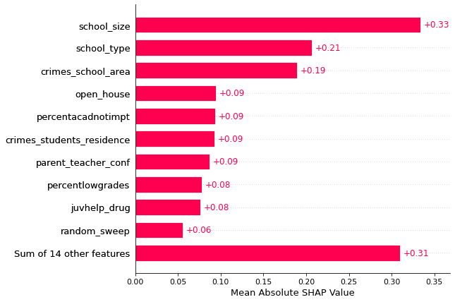

```python
shap.plots.bar(X_shap.abs, max_display=11, show=False)
plt.xlabel("Mean Absolute SHAP Value")
plt.show()
```

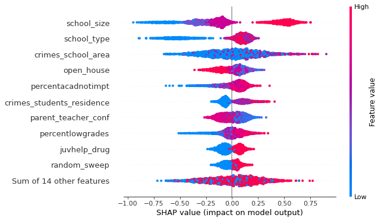

```python
shap.plots.beeswarm(X_shap, max_display=11)
```

## Checking Top 10 Variables

```python
top_subset = X_shap_df[['school_size', 'school_type', 'crimes_school_area', 'open_house','percentacadnotimpt',
        'crimes_students_residence','parent_teacher_conf','percentlowgrades','juvhelp_drug',
        'random_sweep']]
```

```python
top_subset_stats = top_subset.describe(include='all').T

top_subset_stats['mean_absolute_shap'] = X_shap_df.abs().mean()
```

```python
top_subset_stats
```

|  | count | mean | std | min | 25% | 50% | 75% | max | mean_absolute_shap |
| --- | --- | --- | --- | --- | --- | --- | --- | --- | --- |
| school_size | 2762.0 | -0.033485 | 0.389251 | -0.947001 | -0.294673 | -0.122012 | 0.415223 | 0.755017 | 0.334011 |
| school_type | 2762.0 | -0.047268 | 0.277880 | -0.894681 | -0.023091 | 0.080176 | 0.131032 | 0.256140 | 0.206473 |
| crimes_school_area | 2762.0 | 0.012747 | 0.236398 | -0.652974 | -0.157552 | 0.018544 | 0.170326 | 0.903954 | 0.189459 |
| open_house | 2762.0 | 0.005167 | 0.113258 | -0.359999 | -0.081783 | 0.028553 | 0.088601 | 0.308604 | 0.094526 |
| percentacadnotimpt | 2762.0 | 0.015226 | 0.116999 | -0.634378 | -0.035158 | 0.046400 | 0.095095 | 0.360072 | 0.093333 |
| crimes_students_residence | 2762.0 | 0.011909 | 0.106836 | -0.200674 | -0.073752 | -0.036647 | 0.102278 | 0.408037 | 0.092761 |
| parent_teacher_conf | 2762.0 | 0.004202 | 0.102349 | -0.265371 | -0.077920 | 0.009098 | 0.085561 | 0.327269 | 0.086767 |
| percentlowgrades | 2762.0 | 0.001540 | 0.106128 | -0.512474 | -0.048982 | 0.004220 | 0.069999 | 0.345089 | 0.077563 |
| juvhelp_drug | 2762.0 | -0.014673 | 0.084836 | -0.236844 | -0.082430 | -0.027623 | 0.063059 | 0.209903 | 0.075947 |
| random_sweep | 2762.0 | -0.008011 | 0.065915 | -0.203427 | -0.058972 | -0.003920 | 0.044290 | 0.193426 | 0.055412 |

```python
#top_subset_stats.to_csv('top_subset_stats.csv') #save to working directory
```

### Assessing Model Based on Top 10 Only

```python
assessment_top_subset = final_rf.fit(top_subset, y_train)
```

```python
top_subset_assess = X_test[['school_size', 'school_type', 'crimes_school_area', 'open_house','percentacadnotimpt',
        'crimes_students_residence','parent_teacher_conf','percentlowgrades','juvhelp_drug',
        'random_sweep']]
```

```python
y_pred = final_rf.predict(top_subset_assess)
```

```python
model_eval_metrics(y_test, y_pred,classification=False)
```

|  | accuracy | f1_score | precision | recall | mse | rmse | mae | r2 |
| --- | --- | --- | --- | --- | --- | --- | --- | --- |
| 0 | 0 | 0 | 0 | 0 | 1.158845 | 1.076497 | 0.834543 | 0.357993 |

## (For Appendix) SHAP Value Descriptives

```python
shap_descriptives = X_shap_df.describe().T
```

```python
X_shap_df.columns
```

```
Index(['percentlowgrades', 'percentacadnotimpt', 'school_size', 'urban',
       'crimes_students_residence', 'crimes_school_area', 'school_type',
       'control_ground', 'require_check', 'random_sweep', 'wear_uniform',
       'dress_code', 'anonymous_report', 'student_id', 'prohibit_phone',
       'open_house', 'parent_teacher_conf', 'disciplinary_process',
       'juvhelp_drug', 'lawhelp_drug', 'mhhelp_drug', 'privatehelp_drug',
       'relighelp_drug', 'peer_mediation'],
      dtype='object')
```

```python
shap_descriptives['mean_absolute_shap'] = X_shap_df.abs().mean()
shap_descriptives = shap_descriptives.sort_values(by = ['mean_absolute_shap'], ascending = False).round(5)
```

```python
shap_descriptives
```

|  | count | mean | std | min | 25% | 50% | 75% | max | mean_absolute_shap |
| --- | --- | --- | --- | --- | --- | --- | --- | --- | --- |
| school_size | 2762.0 | -0.033 | 0.389 | -0.947 | -0.295 | -0.122 | 0.415 | 0.755 | 0.33401 |
| school_type | 2762.0 | -0.047 | 0.278 | -0.895 | -0.023 | 0.080 | 0.131 | 0.256 | 0.20647 |
| crimes_school_area | 2762.0 | 0.013 | 0.236 | -0.653 | -0.158 | 0.019 | 0.170 | 0.904 | 0.18946 |
| open_house | 2762.0 | 0.005 | 0.113 | -0.360 | -0.082 | 0.029 | 0.089 | 0.309 | 0.09453 |
| percentacadnotimpt | 2762.0 | 0.015 | 0.117 | -0.634 | -0.035 | 0.046 | 0.095 | 0.360 | 0.09333 |
| crimes_students_residence | 2762.0 | 0.012 | 0.107 | -0.201 | -0.074 | -0.037 | 0.102 | 0.408 | 0.09276 |
| parent_teacher_conf | 2762.0 | 0.004 | 0.102 | -0.265 | -0.078 | 0.009 | 0.086 | 0.327 | 0.08677 |
| percentlowgrades | 2762.0 | 0.002 | 0.106 | -0.512 | -0.049 | 0.004 | 0.070 | 0.345 | 0.07756 |
| juvhelp_drug | 2762.0 | -0.015 | 0.085 | -0.237 | -0.082 | -0.028 | 0.063 | 0.210 | 0.07595 |
| random_sweep | 2762.0 | -0.008 | 0.066 | -0.203 | -0.059 | -0.004 | 0.044 | 0.193 | 0.05541 |
| mhhelp_drug | 2762.0 | 0.008 | 0.052 | -0.174 | -0.026 | 0.027 | 0.042 | 0.116 | 0.04473 |
| anonymous_report | 2762.0 | -0.002 | 0.054 | -0.237 | -0.041 | 0.007 | 0.040 | 0.151 | 0.04421 |
| urban | 2762.0 | 0.006 | 0.043 | -0.239 | 0.003 | 0.020 | 0.031 | 0.096 | 0.03441 |
| prohibit_phone | 2762.0 | -0.003 | 0.038 | -0.120 | -0.031 | -0.010 | 0.023 | 0.115 | 0.03166 |
| control_ground | 2762.0 | -0.003 | 0.032 | -0.140 | -0.021 | 0.002 | 0.019 | 0.113 | 0.02515 |
| dress_code | 2762.0 | 0.000 | 0.032 | -0.136 | -0.018 | 0.001 | 0.020 | 0.144 | 0.02451 |
| relighelp_drug | 2762.0 | 0.004 | 0.032 | -0.074 | -0.015 | -0.005 | 0.014 | 0.202 | 0.02230 |
| student_id | 2762.0 | 0.003 | 0.034 | -0.110 | -0.011 | -0.006 | 0.000 | 0.277 | 0.01721 |
| disciplinary_process | 2762.0 | 0.001 | 0.020 | -0.086 | -0.011 | 0.002 | 0.014 | 0.069 | 0.01596 |
| peer_mediation | 2762.0 | 0.002 | 0.019 | -0.071 | -0.009 | 0.002 | 0.013 | 0.083 | 0.01430 |
| privatehelp_drug | 2762.0 | 0.000 | 0.019 | -0.066 | -0.010 | -0.001 | 0.008 | 0.152 | 0.01344 |
| lawhelp_drug | 2762.0 | -0.003 | 0.025 | -0.191 | -0.001 | 0.003 | 0.006 | 0.095 | 0.01120 |
| wear_uniform | 2762.0 | -0.000 | 0.018 | -0.143 | -0.003 | 0.002 | 0.005 | 0.164 | 0.00919 |
| require_check | 2762.0 | -0.001 | 0.008 | -0.146 | -0.001 | -0.000 | 0.000 | 0.046 | 0.00165 |

```python
#shap_descriptives.to_csv('shap_descriptives.csv') #save to working directory
```